# Project - Machine Learning

### 2.1 Find the number of characters, words, and sentences for the mentioned documents.

```python
#First let's check all the raw files separately

Roosevelt_raw
```

```
'On each national day of inauguration since 1789, the people have renewed their sense of dedication to the United States.\n\nIn Washington\'s day the task of the people was to create and weld together a nation.\n\nIn Lincoln\'s day the task of the people was to preserve that Nation from disruption f…
```

```python
#Raw file of Kennedy

Kennedy_raw
```

```
'Vice President Johnson, Mr. Speaker, Mr. Chief Justice, President Eisenhower, Vice President Nixon, President Truman, reverend clergy, fellow citizens, we observe today not a victory of party, but a celebration of freedom -- symbolizing an end, as well as a beginning -- signifying renewal, as well …
```

```python
#raw file of Nixon

Nixon_raw
```

```
'Mr. Vice President, Mr. Speaker, Mr. Chief Justice, Senator Cook, Mrs. Eisenhower, and my fellow citizens of this great and good country we share together:\n\nWhen we met here four years ago, America was bleak in spirit, depressed by the prospect of seemingly endless war abroad and of destructive c…
```

### Now, let's check length of all 3 files

```python
print('Length of Roosevelt_raw:', len(Roosevelt_raw))
print()
print('Length of Kennedy_raw:', len(Kennedy_raw))
print()
print('Length of Nixon_raw:', len(Nixon_raw))
```

```
Length of Roosevelt_raw: 7571

Length of Kennedy_raw: 7618

Length of Nixon_raw: 9991
```

### Removing unwanted characters

```python
unwanted_chars = [';', ':', '!', "*", '--', '``','""']

# using replace() to
# remove bad_chars
for i in unwanted_chars :
    Roosevelt_raw = Roosevelt_raw.replace(i, '')
```

```python
for i in unwanted_chars :
    Kennedy_raw = Kennedy_raw.replace(i, '')
```

```python
for i in unwanted_chars :
    Nixon_raw = Nixon_raw.replace(i, '')
```

```python
# Removing additional space from string using re.sub()

import re

extra_space_remove_R = re.sub(' +', ' ', Roosevelt_raw)
extra_space_remove_K = re.sub(' +', ' ', Kennedy_raw)
extra_space_remove_N = re.sub(' +', ' ', Nixon_raw)
```

```python
#removing punctuations

re.sub("[^-9A-Za-z ]", "" , Roosevelt_raw)
re.sub("[^-9A-Za-z ]", "" , Kennedy_raw)
re.sub("[^-9A-Za-z ]", "" , Nixon_raw)
```

```
'Mr Vice President Mr Speaker Mr Chief Justice Senator Cook Mrs Eisenhower and my fellow citizens of this great and good country we share togetherWhen we met here four years ago America was bleak in spirit depressed by the prospect of seemingly endless war abroad and of destructive conflict at homeA…
```

```python
#case normalization(all upper case to lower case conversion)

Roosevelt_raw = Roosevelt_raw.lower()
Kennedy_raw = Kennedy_raw.lower()
Nixon_raw = Nixon_raw.lower()
```

```python
#Again Checking length

print('Length of Roosevelt_raw:', len(Roosevelt_raw))
print()
print('Length of Kennedy_raw:', len(Kennedy_raw))
print()
print('Length of Nixon_raw:', len(Nixon_raw))
```

```
Length of Roosevelt_raw: 7515

Length of Kennedy_raw: 7563

Length of Nixon_raw: 9951
```

### Now let's check number of sentences in all speeches

#### tokenization

```python
R_tokens = nltk.word_tokenize(Roosevelt_raw)

print('length of tokens:',len(R_tokens))

print(R_tokens[:10])  #print top 10 tokens

print('-------------------------------------')

K_tokens = nltk.word_tokenize(Kennedy_raw)

print('length of tokens:',len(K_tokens))

print(K_tokens[:10])  #print top 10 tokens

print('-------------------------------------')


N_tokens = nltk.word_tokenize(Nixon_raw)

print('length of tokens:',len(N_tokens))

print(N_tokens[:10])  #print top 10 tokens
```

```
length of tokens: 1492
['on', 'each', 'national', 'day', 'of', 'inauguration', 'since', '1789', ',', 'the']
-------------------------------------
length of tokens: 1512
['vice', 'president', 'johnson', ',', 'mr.', 'speaker', ',', 'mr.', 'chief', 'justice']
-------------------------------------
length of tokens: 1983
['mr.', 'vice', 'president', ',', 'mr.', 'speaker', ',', 'mr.', 'chief', 'justice']
```

```python
#Number of sentences in Roosevelt's speech

R_sentences= nltk.sent_tokenize(Roosevelt_raw)

R_length= len(R_sentences)

print("Number of sentences in Roosevelt's speech:",R_length)
```

```
Number of sentences in Roosevelt's speech: 68
```

```python
#Number of sentences in Kennedy's speech

K_sentences= nltk.sent_tokenize(Kennedy_raw)

K_length= len(K_sentences)

print("Number of sentences in Kennedy's speech:",K_length)
```

```
Number of sentences in Kennedy's speech: 52
```

```python
#Number of sentences in Nixon's speech

N_sentences= nltk.sent_tokenize(Nixon_raw)

N_length= len(N_sentences)

print("Number of sentences in Nixon's speech:",N_length)
```

```
Number of sentences in Nixon's speech: 68
```

#### We will use nltk.Text(tokens) function on the tokens and further do more linguistic processing using text.

```python
R_text = nltk.Text(R_tokens)
```

```python
K_text = nltk.Text(K_tokens)
```

```python
N_text = nltk.Text(N_tokens)

type(N_text)
```

```
nltk.text.Text
```

#### Checking some random texts from all 3

```python
print('Checking texts from R_text:\n\n',R_text[820:835])
print('------------------------------\n')
print('Checking texts from K_text:\n\n',K_text[700:720])
print('------------------------------\n')
print('Checking texts from N_text:\n\n',N_text[900:910])
print()
```

```
Checking texts from R_text:

 ['the', 'democratic', 'aspiration', 'is', 'no', 'mere', 'recent', 'phase', 'in', 'human', 'history', '.', 'it', 'is', 'human']
------------------------------

Checking texts from K_text:

 ['area', 'in', 'which', 'its', 'writ', 'may', 'run', '.', 'finally', ',', 'to', 'those', 'nations', 'who', 'would', 'make', 'themselves', 'our', 'adversary', ',']
------------------------------

Checking texts from N_text:

 ['to', 'new', 'has', 'not', 'been', 'a', 'retreat', 'from', 'our', 'responsibilities']
```

### 2.2 Remove all the stopwords from all three speeches.

```python
#Below are the common stopwords

from nltk.corpus import stopwords

print(stopwords.words('english'))
```

```
['i', 'me', 'my', 'myself', 'we', 'our', 'ours', 'ourselves', 'you', "you're", "you've", "you'll", "you'd", 'your', 'yours', 'yourself', 'yourselves', 'he', 'him', 'his', 'himself', 'she', "she's", 'her', 'hers', 'herself', 'it', "it's", 'its', 'itself', 'they', 'them', 'their', 'theirs', 'themselve…
```

```python
#Removing the stopwords from Roosevelt speech(R_text)

#R_tokens is tokenization for Roosevelt

stop_words = set(stopwords.words('english') +list(string.punctuation))

Roosevelt_without_stopwords_punc = [w for w in R_tokens if w.lower() not in stop_words]

Roosevelt_without_stopwords_punc = []

for w in R_tokens:
    if w not in stop_words:
        Roosevelt_without_stopwords_punc.append(w)

print(Roosevelt_without_stopwords_punc)
```

```
['national', 'day', 'inauguration', 'since', '1789', 'people', 'renewed', 'sense', 'dedication', 'united', 'states', 'washington', "'s", 'day', 'task', 'people', 'create', 'weld', 'together', 'nation', 'lincoln', "'s", 'day', 'task', 'people', 'preserve', 'nation', 'disruption', 'within', 'day', 'ta…
```

```python
len(Roosevelt_without_stopwords_punc)
```

```
632
```

```python
#Removing the stopwords from Kennedy speech

#K_tokens is tokenization for Kennedy

stop_words = set(stopwords.words('english') +list(string.punctuation))

Kennedy_without_stopwords_punc = [w for w in K_tokens if w.lower() not in stop_words]

Kennedy_without_stopwords_punc = []

for w in K_tokens:
    if w not in stop_words:
        Kennedy_without_stopwords_punc.append(w)

print(Kennedy_without_stopwords_punc)
```

```
['vice', 'president', 'johnson', 'mr.', 'speaker', 'mr.', 'chief', 'justice', 'president', 'eisenhower', 'vice', 'president', 'nixon', 'president', 'truman', 'reverend', 'clergy', 'fellow', 'citizens', 'observe', 'today', 'victory', 'party', 'celebration', 'freedom', 'symbolizing', 'end', 'well', 'b…
```

```python
len(Kennedy_without_stopwords_punc)
```

```
696
```

```python
#Removing the stopwords from Nixon speech

#N_tokens is tokenization for Nixon

stop_words = set(stopwords.words('english') +list(string.punctuation))

Nixon_without_stopwords_punc = [w for w in N_tokens if w.lower() not in stop_words]

Nixon_without_stopwords_punc = []

for w in N_tokens:
    if w not in stop_words:
        Nixon_without_stopwords_punc.append(w)

print(Nixon_without_stopwords_punc)
print('-----------')
print(N_tokens)
```

```
['mr.', 'vice', 'president', 'mr.', 'speaker', 'mr.', 'chief', 'justice', 'senator', 'cook', 'mrs.', 'eisenhower', 'fellow', 'citizens', 'great', 'good', 'country', 'share', 'together', 'met', 'four', 'years', 'ago', 'america', 'bleak', 'spirit', 'depressed', 'prospect', 'seemingly', 'endless', 'war…
-----------
['mr.', 'vice', 'president', ',', 'mr.', 'speaker', ',', 'mr.', 'chief', 'justice', ',', 'senator', 'cook', ',', 'mrs.', 'eisenhower', ',', 'and', 'my', 'fellow', 'citizens', 'of', 'this', 'great', 'and', 'good', 'country', 'we', 'share', 'together', 'when', 'we', 'met', 'here', 'four', 'years', 'ag…
```

```python
print(len(Nixon_without_stopwords_punc))

print(len(N_tokens))
```

```
848
1983
```

### 2.3 Which word occurs the most number of times in his inaugural address for each president? Mention the top three words. (after removing the stopwords)

```python
#Checking most occuring words

word_freq_Roosevelt = nltk.FreqDist(Roosevelt_without_stopwords_punc)

word_freq_Roosevelt.most_common(3)
```

```
[('nation', 12), ('know', 10), ('spirit', 9)]
```

```python
word_freq_Kennedy = nltk.FreqDist(Kennedy_without_stopwords_punc)

word_freq_Kennedy.most_common(3)
```

```
[('let', 16), ('us', 12), ('world', 8)]
```

```python
word_freq_Nixon = nltk.FreqDist(Nixon_without_stopwords_punc)

word_freq_Nixon.most_common(3)
```

```
[('us', 26), ('let', 22), ('america', 21)]
```

### 2.4 Plot the word cloud of each of the speeches of the variable. (after removing the stopwords)

```python
# Import package
import matplotlib.pyplot as plt

# Defining a function to plot word cloud
def plot_cloud(wordcloud):
    plt.figure(figsize=(40, 30))
    plt.imshow(wordcloud)
    plt.axis("off");
```

```python
# Import package
from wordcloud import WordCloud, STOPWORDS
```

```python
Ro_string = str(Roosevelt_without_stopwords_punc)
Ke_string = str(Kennedy_without_stopwords_punc)
Ni_string = str(Nixon_without_stopwords_punc)


#removing punctuations

re.sub("[^-9A-Za-z ]", "" , Ro_string)
re.sub("[^-9A-Za-z ]", "" , Ke_string)
re.sub("[^-9A-Za-z ]", "" , Ni_string)
```

```
'mr vice president mr speaker mr chief justice senator cook mrs eisenhower fellow citizens great good country share together met four years ago america bleak spirit depressed prospect seemingly endless war abroad destructive conflict home meet today stand threshold new era peace world central questi…
```

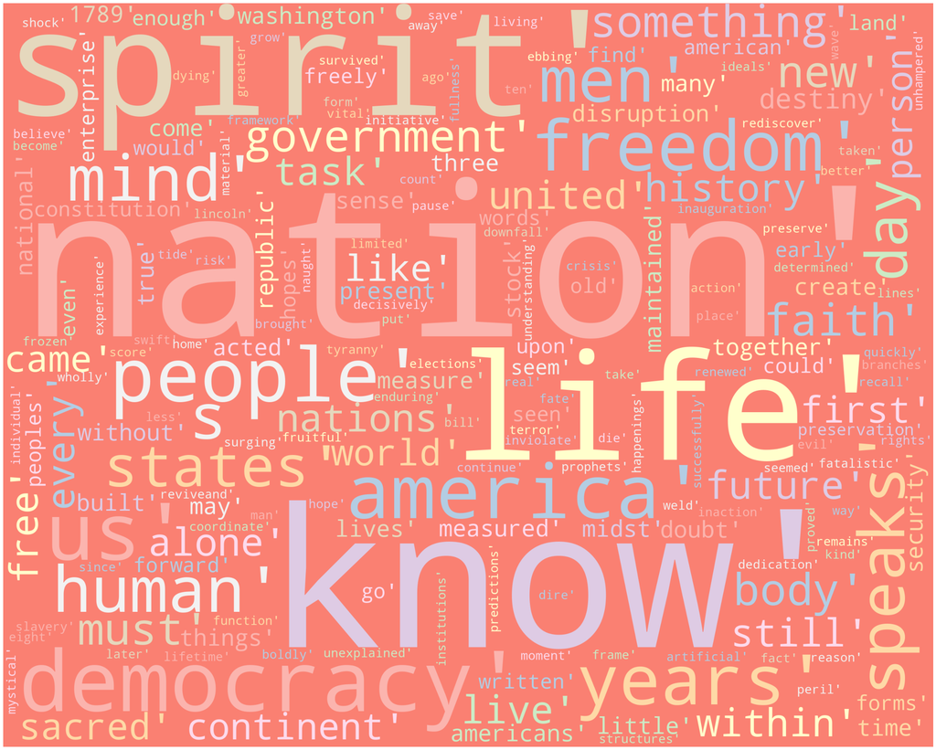

```python
# Generate word cloud
wordcloud = WordCloud(width = 2500, height = 2000, random_state=1, background_color='salmon', colormap='Pastel1', collocations=False, stopwords = STOPWORDS).generate(Ro_string)
# Plot
plot_cloud(wordcloud)
```

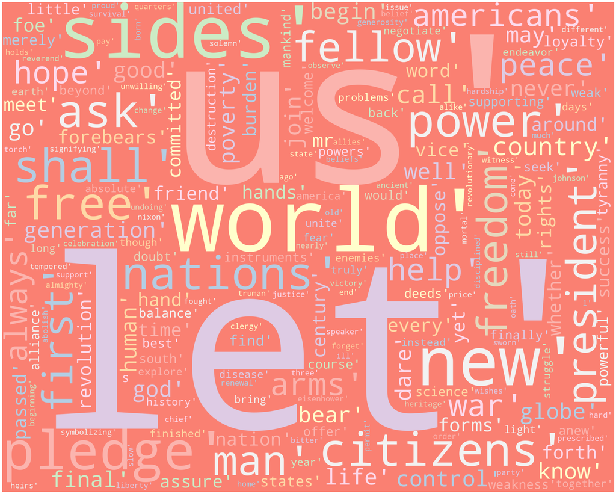

```python
# Generate word cloud
wordcloud = WordCloud(width = 2500, height = 2000, random_state=1, background_color='salmon', colormap='Pastel1', collocations=False, stopwords = STOPWORDS).generate(Ke_string)
# Plot
plot_cloud(wordcloud)
```

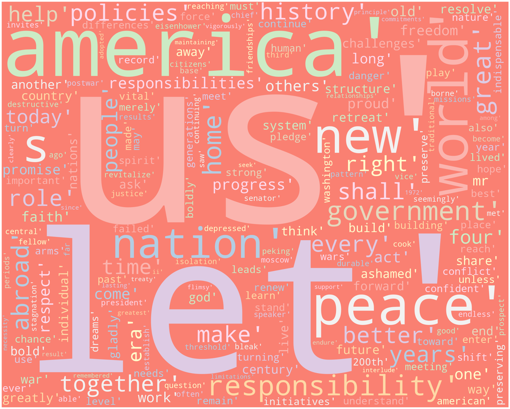

```python
# Generate word cloud
wordcloud = WordCloud(width = 2500, height = 2000, random_state=1, background_color='salmon', colormap='Pastel1', collocations=False, stopwords = STOPWORDS).generate(Ni_string)
# Plot
plot_cloud(wordcloud)
```

**_**THE END**___**